# Optimal Excercise with Machine Learning

Scott Roberts

May 30, 2016

## Synopsis

The goal of this project was to determine how an excercise was done by the study’s participant. Building a model with the data provided from the accelerometers will involve classification models. With the number of dimensions in the data a number of models could be chosen for this prediction problem. Of, the models built and analysed, the Random Forest model had the highest accuracy.

# Building the Model

First, in order to build the model, we first load the training data and do some basic exploratory analysis and inspect the dimensions. There are a lot of NA values for over 100 of the variables. So, we reduce the variables to include dimensions with useful data. the resulting dataframe had 51 variables. 53 variables had usefule data, but two variables, were just totals for each window.

The second model, the Generalized Boosted Regression Model was much more accurate than the CART model. There was still room for improvement, so I built a Random Forest model. This latest model proved to be quite accurate, slightly more accurate than the GBM model.

## Conclusion

From the resulting high Accuracy and Kappa, the Random Forest model performed much better, and used it for the 20 test cases. Confident the model would predict all cases more accurately than the CART or gbm models.

## Reference

Velloso, E.; Bulling, A.; Gellersen, H.; Ugulino, W.; Fuks, H. Qualitative Activity Recognition of Weight Lifting Exercises. Proceedings of 4th International Conference in Cooperation with SIGCHI (Augmented Human ’13) . Stuttgart, Germany: ACM SIGCHI, 2013.

Read more: http://groupware.les.inf.puc-rio.br/har#ixzz4AxdwI56w

# Explore the Data

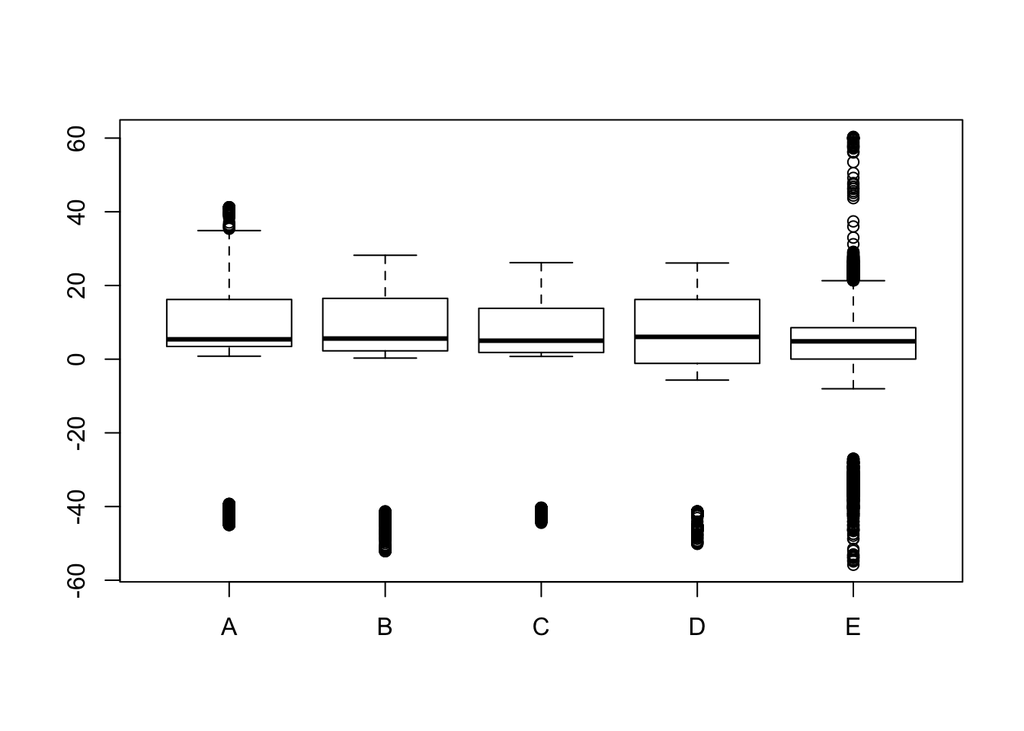

```
## CART
##
## 19622 samples
##    51 predictor
##     5 classes: 'A', 'B', 'C', 'D', 'E'
##
## No pre-processing
## Resampling: Bootstrapped (25 reps)
## Summary of sample sizes: 19622, 19622, 19622, 19622, 19622, 19622, ...
## Resampling results across tuning parameters:
##
##   cp          Accuracy   Kappa
##   0.03567868  0.5116189  0.36470465
##   0.05998671  0.4176342  0.21079440
##   0.11515454  0.3303068  0.07009912
##
## Accuracy was used to select the optimal model using  the largest value.
## The final value used for the model was cp = 0.03567868.
```

```
##  [1] C A C A A C C A A A C C C A C A A A A C
## Levels: A B C D E
```

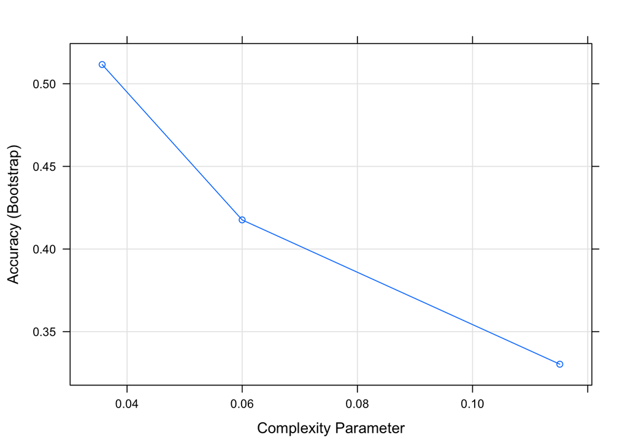

```
## Stochastic Gradient Boosting
##
## 19622 samples
##    51 predictor
##     5 classes: 'A', 'B', 'C', 'D', 'E'
##
## No pre-processing
## Resampling: Cross-Validated (3 fold, repeated 3 times)
## Summary of sample sizes: 13080, 13082, 13082, 13082, 13082, 13080, ...
## Resampling results across tuning parameters:
##
##   interaction.depth  n.trees  Accuracy   Kappa
##   1                   50      0.7511466  0.6844415
##   1                  100      0.8186221  0.7704343
##   1                  150      0.8526823  0.8135948
##   2                   50      0.8534975  0.8143751
##   2                  100      0.9067370  0.8819683
##   2                  150      0.9313183  0.9130858
##   3                   50      0.8938945  0.8656801
##   3                  100      0.9416809  0.9261965
##   3                  150      0.9605203  0.9500501
##
## Tuning parameter 'shrinkage' was held constant at a value of 0.1
##
## Tuning parameter 'n.minobsinnode' was held constant at a value of 10
## Accuracy was used to select the optimal model using  the largest value.
## The final values used for the model were n.trees = 150,
##  interaction.depth = 3, shrinkage = 0.1 and n.minobsinnode = 10.
```

```
##  [1] B A B A A E D B A A B C B A E E A B B B
## Levels: A B C D E
```

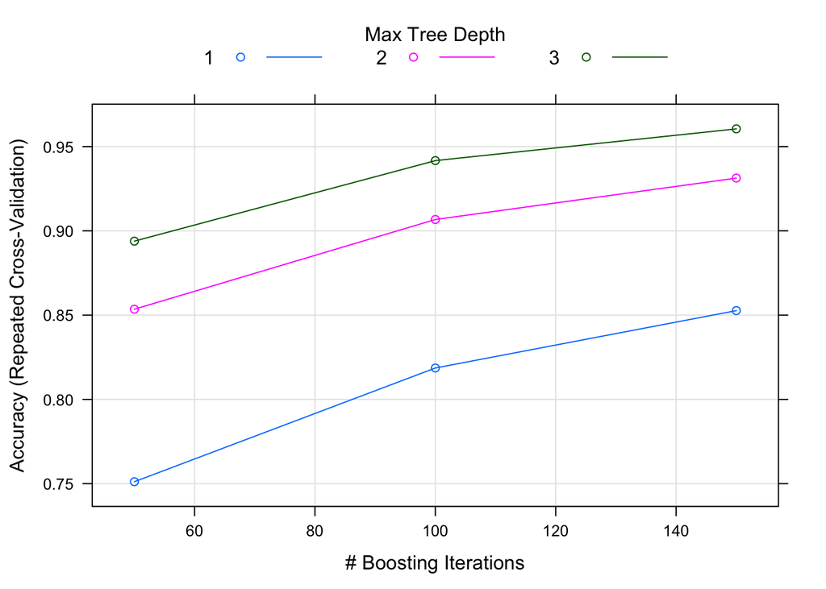

```
## Random Forest
##
## 19622 samples
##    51 predictor
##     5 classes: 'A', 'B', 'C', 'D', 'E'
##
## No pre-processing
## Resampling: Bootstrapped (25 reps)
## Summary of sample sizes: 19622, 19622, 19622, 19622, 19622, 19622, ...
## Resampling results across tuning parameters:
##
##   mtry  Accuracy   Kappa
##    2    0.9930767  0.9912414
##   26    0.9918291  0.9896634
##   51    0.9856934  0.9819003
##
## Accuracy was used to select the optimal model using  the largest value.
## The final value used for the model was mtry = 2.
```

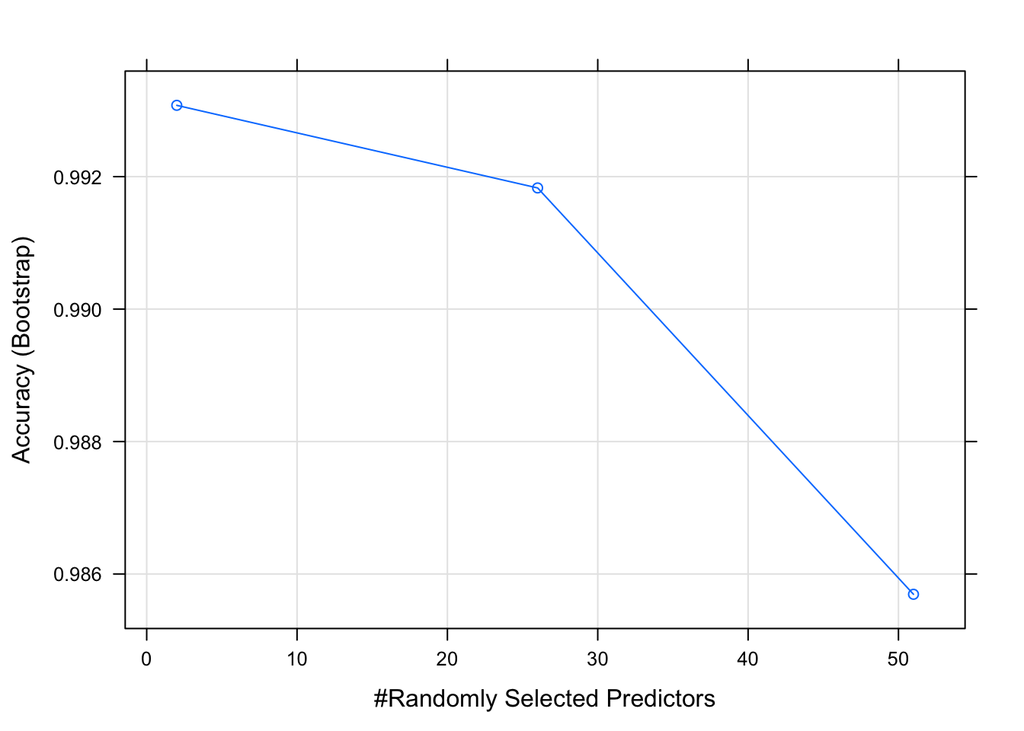

```
##  [1] B A B A A E D B A A B C B A E E A B B B
## Levels: A B C D E
```